# Fundamentals of Data Science MA7419

DABI_b_3_MA7419_CW2

Pranav S Asalekar (psa8), Srijeet Mohan Nair (smn24), Sahithi Devarapalli (sd592), Lakshmi Mahitha Kodali (lmk22)

# Identifying and Evaluating Data Source: Stats 19

1. Stat19 Data is open and free to use which is about road traffic accidents
2. The data is published annually by UK government.
3. The dataset is also available on DfT or UK Data Archive website.
4. Focusing on Birmingham and Wolverhampton data for year 2019 and 2020.
5. Integrating Vehicle, Accident and Casualty dataset to answer the question.
6. Analyzing actual data which is required to use for project purpose.

# Ethical, Regulatory and Privacy Issues potentially encountered

Issues encountered while selecting data and evaluation:

1. Mainly focusing on stat19 vehicle, accidents, casualty dataset for year 2019-2020 for Birmingham & Wolverhampton to analyse on pre-covid and during covid.
2. Stat19 library for dataset accidents, casualty and stat19 dataset in csv format for vehicles for year 2019-2020.

Issues encountered while cleaning the data:

1. Removing non-required columns from dataset like ‘datetime’ which was duplicate for two columns ‘Date’ and ‘Time’.
2. Missing of data from column which could have been useful for further analysis, like ‘Age of Casualty’ which only had ‘NA’ and ‘Data missing’ as values.

# Determining the number of casualties reported by the cities that would be used for comparison, in UK. (UK cities statistics)

- The pie chart presented compares the statistics of casualties recorded in the cities like Birmingham, Manchester, Leicester, Sheffield, Leeds, and Wolverhampton during the year 2019 and the year 2020.
- The maximum number of casualties were recorded in Birmingham for both 2019 and 2020
- Birmingham 2019 and 2020 data when combined with Wolverhampton gives a huge number of casualty records

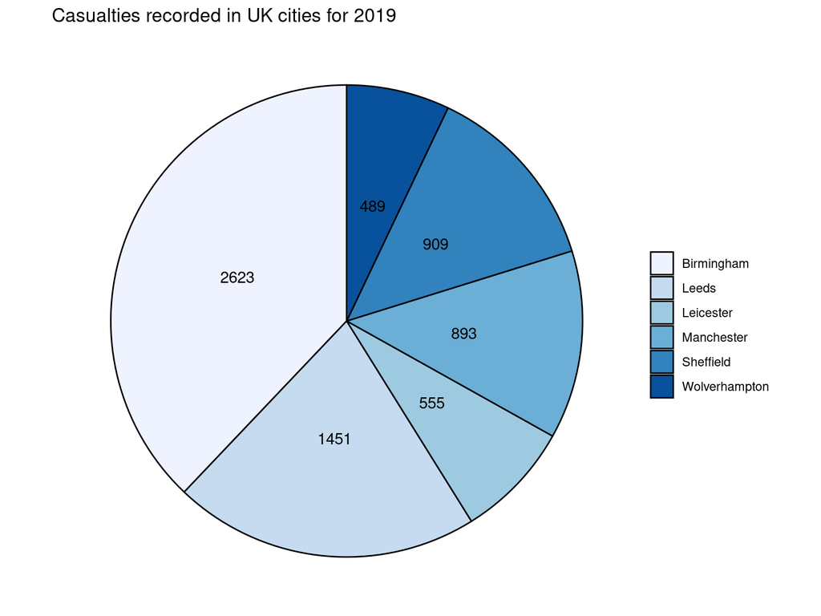

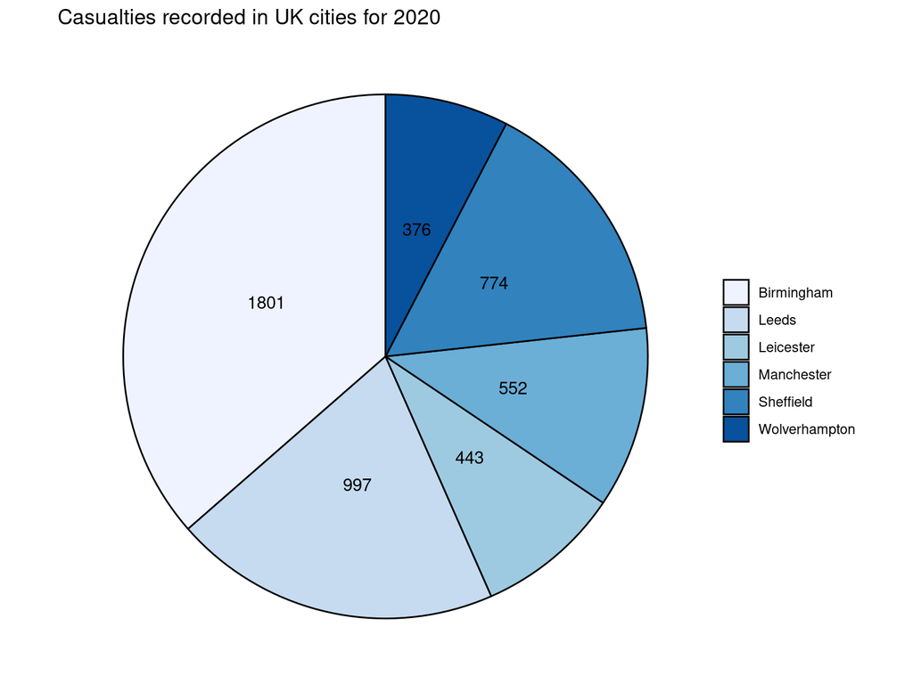

# Analyse the accident rates only during the weekends in the year 2019 and 2020. Also return the maximum and minimum age band of casualties considering them to be a driver or rider, pedestrian.

- A line graph on bar chat is created for 2019 and 2020 comparative analysis.
- Maximum Casualty Age Group = 26 - 35 years
- Minimum Casualty Age Group = 0 -5 years
- No age group more than 100 casualties in 2020

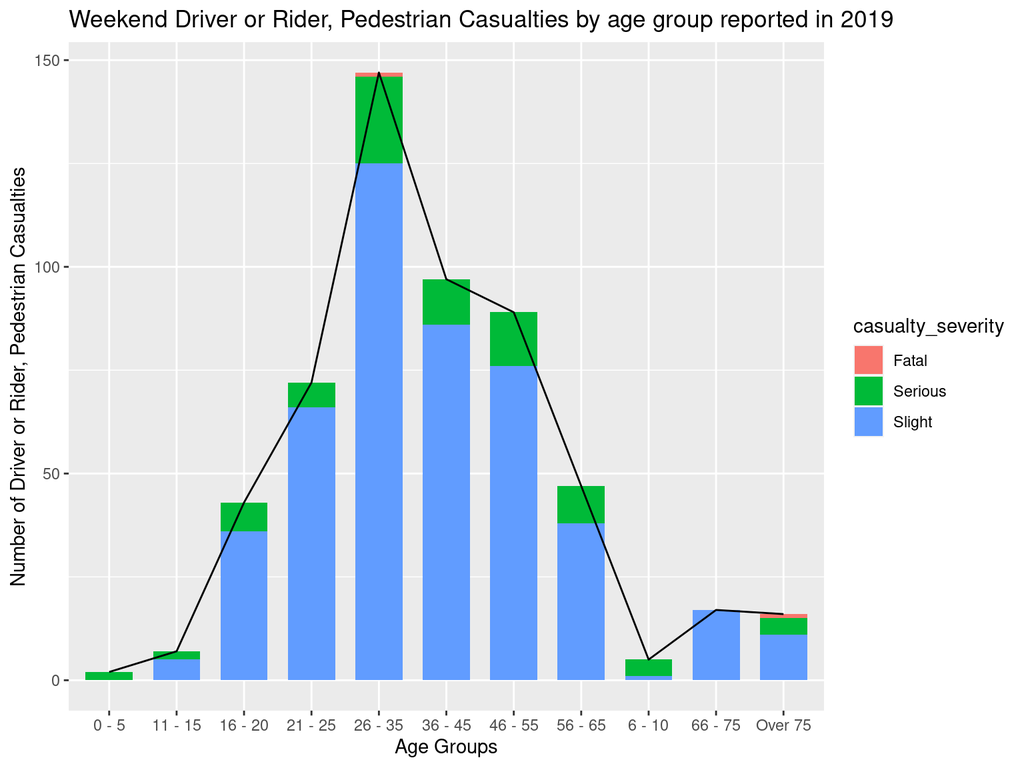

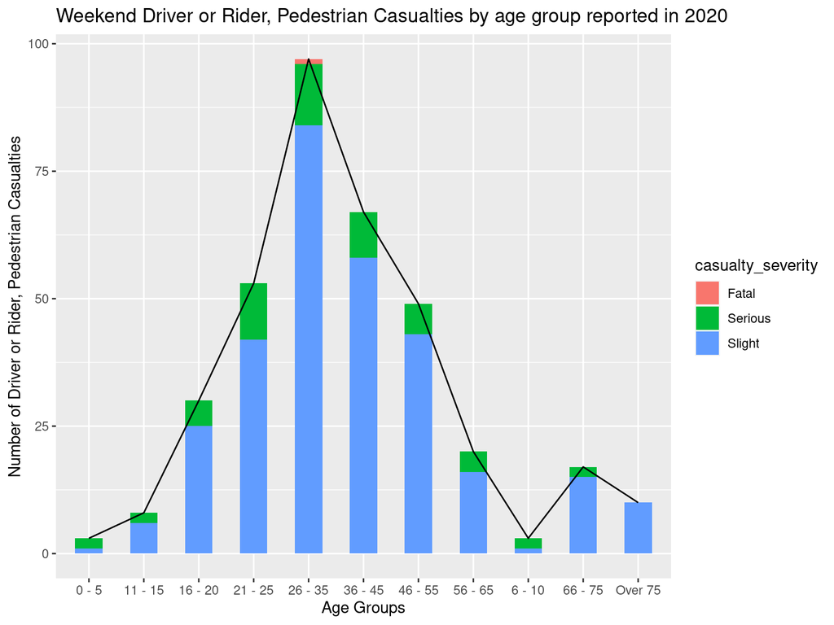

# Estimating the count of driver or rider, pedestrian casualties reported during weekends in 2019 and 2020.

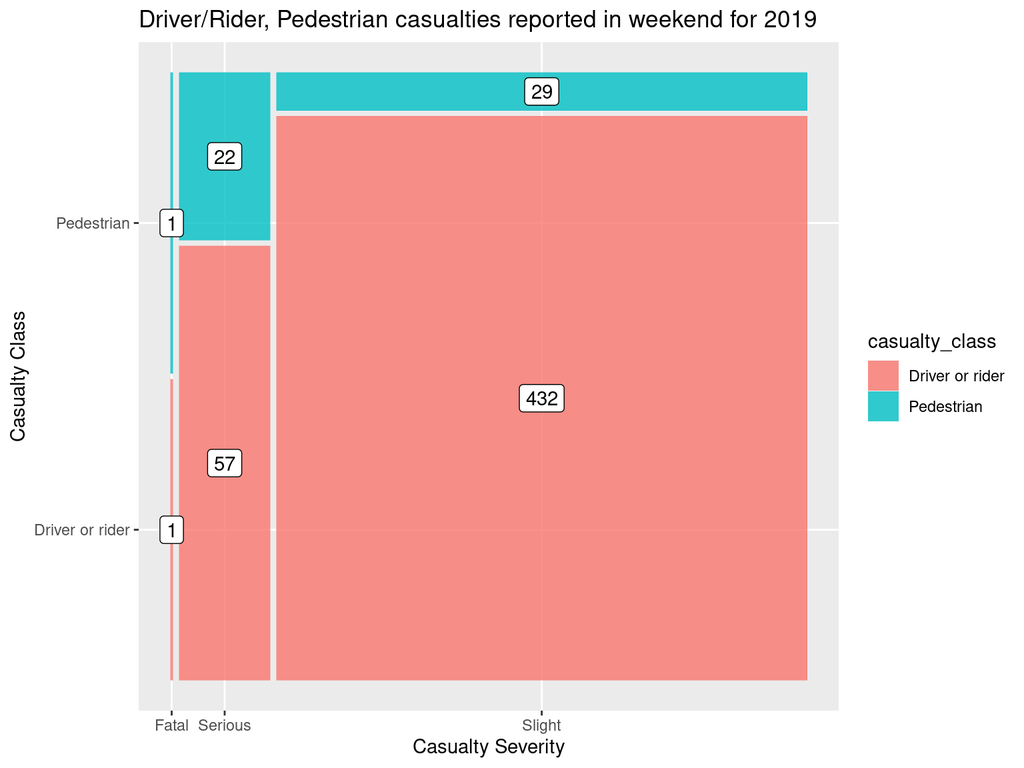

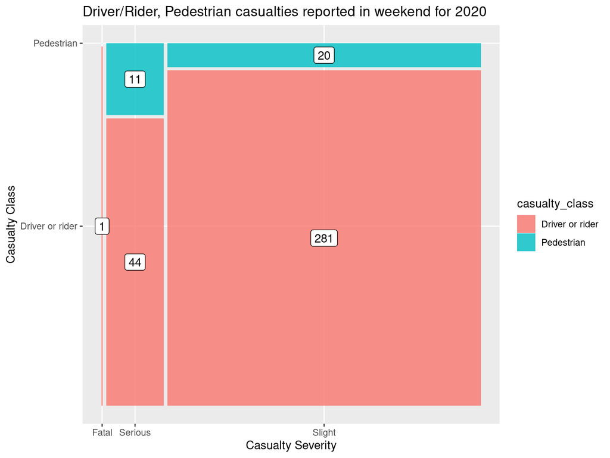

# Analyze the number of casualties on the basis of direction of vehicle travelling towards, in Birmingham for 2019 and 2020.

- Bar graph is used to estimate the number of casualties based on a specific travelling direction of vehicle in Birmingham for 2019 and 2020.
- In 2019, maximum casualty was 384 with vehicles moving towards North and South whereas in 2020 the maximum casualty was 144 with the vehicle moving towards East and West.

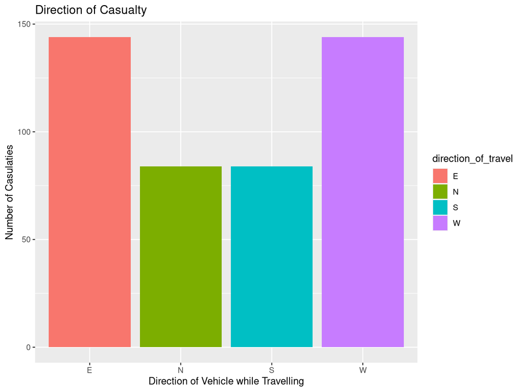

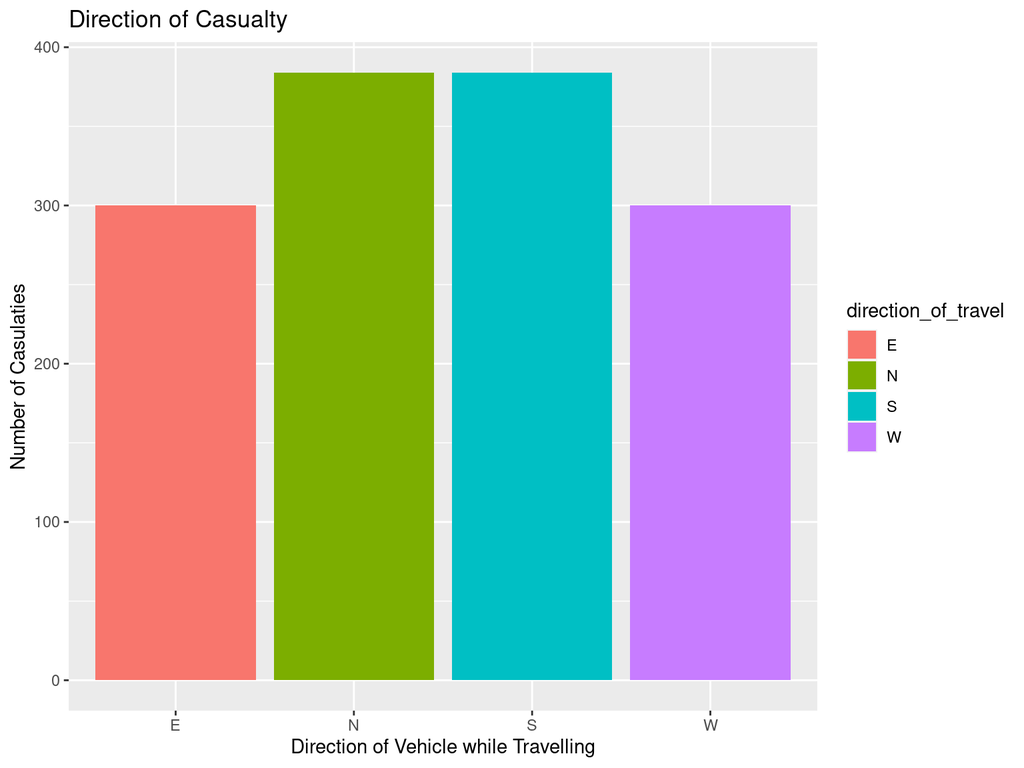

# Conclusion from the data visualisation plots

- The casualties reported due to the road accidents in 2020 is less when compared to 2019.
- Reason can be the pandemic due to which many restrictions, rules and regulations being imposed by the government.

# Possible future work

For such statistical data, out of many researches, few are included to highlight the potential future-work:

1. The question of whether the same results can be repeated using reproducible methods is raised by this study on 20 mph zones, for instance, which implies that areas with 20 mph speed limits are safer.
2. Identify the main causes of traffic accidents and investigate how these causes vary across areas with recent speed limit increases and those without.
3. What does this mean for regions where the speed limit hasn’t changed recently, and does it apply to the 20-mph zone?